# HW1

## Домашнее задание 1. Введение в pymol

### Горохов Никита

```python
from xmlrpclib import ServerProxy
from IPython.display import Image, display
import os, sys
```

```python
import __main__

__main__.pymol_argv = [ 'pymol', '-cp' ]

import pymol

pymol.finish_launching()

from pymol import cmd
```

## Часть 1

### Посмотрите, как выглядит Ваш белок!

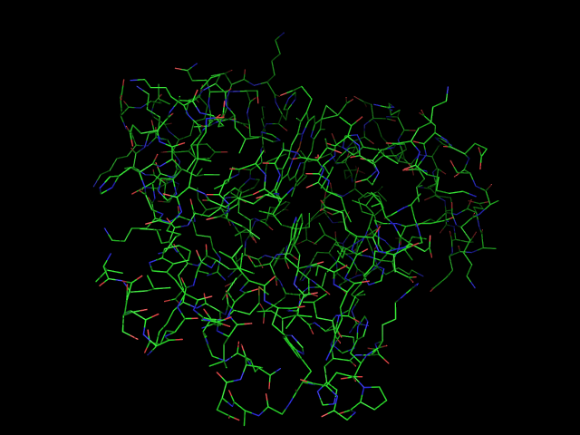

```python
cmd.fetch("1MBN") # ждем когда скачается
cmd.png("1mbn.png")
Image(filename="1mbn.png")
```

## Часть 2

### Работа в командном окне. Разные типы моделей структуры.

```python
#cmd.reinitialize()
cmd.do('''
hide all
fetch 1mbn
as lines, 1mbn
png lines.png
as sticks, 1mbn
png sticks.png
as cartoon, 1mbn
png cartoon.png
as ribbon, 1mbn
png ribbon.png
as spheres, 1mbn
png all.png
''')
```

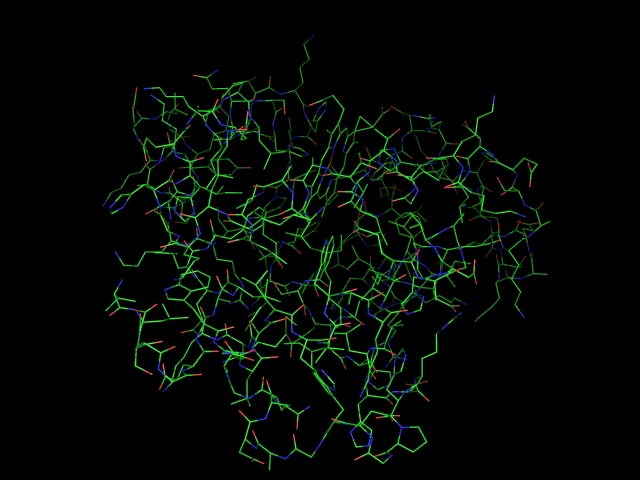

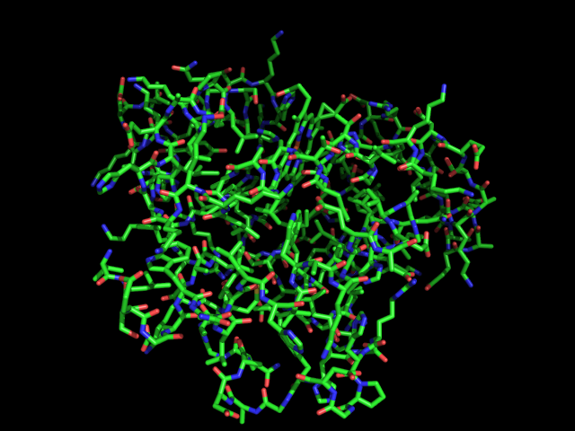

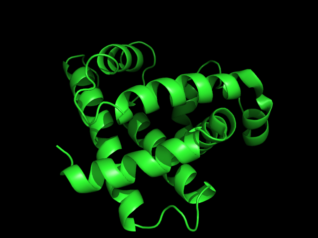

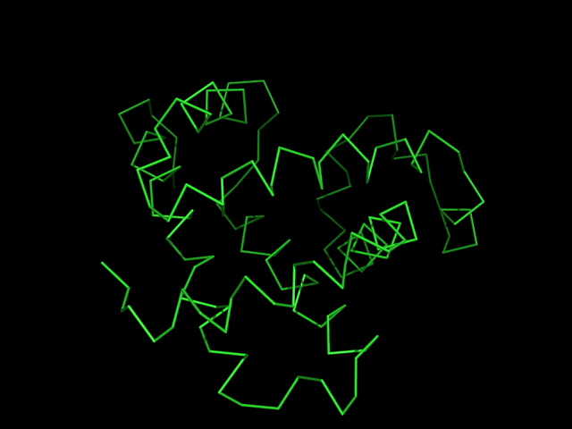

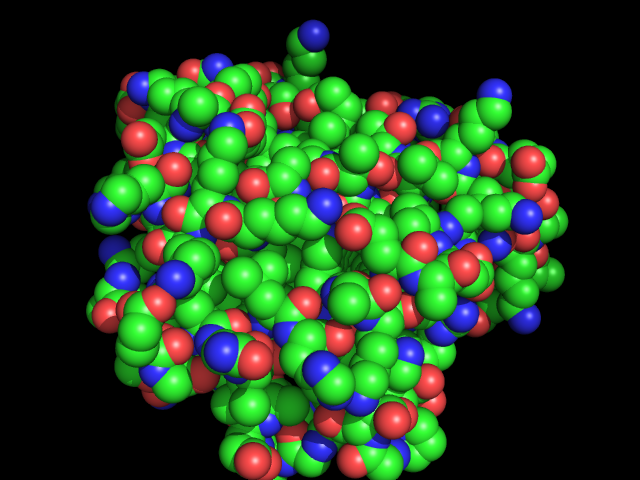

```python
display(Image(filename="lines.png"),
       Image(filename="sticks.png"),
       Image(filename="cartoon.png"),
       Image(filename="ribbon.png"),
       Image(filename="all.png"))
```

## Часть 4

### Создайте скрипт, последовательно генерирующий заданные изображения структуры

1. всю структуру в шариковой модели (сохранили на прошлом этапе, **all.png**)
2. структуру только белка в остовной модели (**sticks_prot.png**)
3. структуру только белка в ленточной модели (**ribbon_prot.png**)
4. изображение всех компонентов структуры;
   - лиганды из 2-х и более атомов, а также ДНК – в шарнирной модели с раскраской по атомам (шарнирной моделью будем называть наложение шариковой и проволочной моделей такое, что размер "проволочек" примерно вдвое меньше размера "шариков");
   - молекулы воды и одноатомные лиганды - в шариковой модели; эту картинку экспортируйте в графический файл **all_components.png**;
5. изображение концевых остатков у одной полипептидной цепи;
   - получите изображение в остовной модели только какой-нибудь одной полипептидной цепи; N- и С-концевые аминокислотные остатки покажите в шарнирной модели, подпишите их названия и номера; представьте аминогруппу N-концевого остатка и атомы кислорода карбоксильной группы С-концевого в шариковой модели (с большим диаметром шариков, чем для остальных атомов); подпишите их названия.

```python
cmd.do('''
hide all
as sticks, polymer.protein

hide all
as ribbon, polymer.protein
''')
```

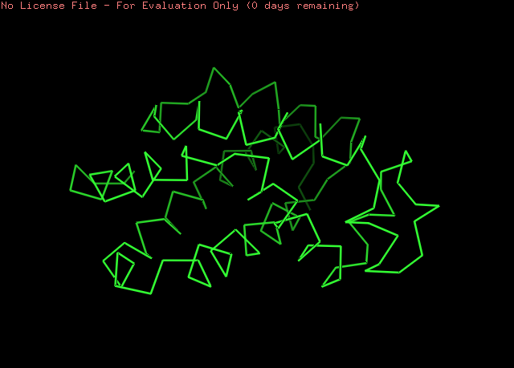

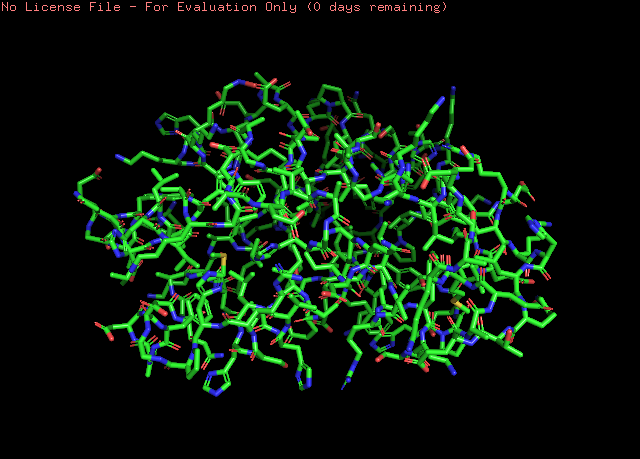

```python
display(Image(filename="ribbon_prot.png"),
        Image(filename="sticks_prot.png"))
```

```python
cmd.do('''
hide all
show sticks, polymer or organic
show spheres, organic or solvent
set_bond stick_radius, 0.15, all
set sphere_scale, 0.3, all
png all_components.png
''')
```

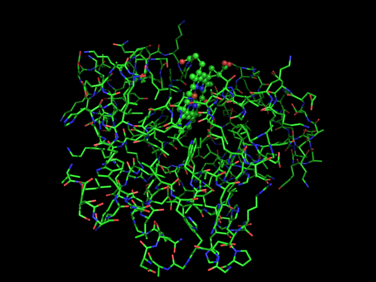

```python
Image(filename='all_components.png')
```

```python
cmd.do('''
hide all
show sticks, chain A and name CA+C+N
show spheres, resi 1 or resi 153
show sticks, resi 1 or resi 153
label resi 1 and name CA, "(%s, %s)" % (resn, resi)
label resi 153 and name CA, "(%s, %s)" % (resn, resi)
set sphere_scale, 0.45, name N and resi 1 or name O and resi 153
label n. O and i. 153, "(%s)" % (name)
label n. N and i. 1, "(%s)" % (name)
png chain.png
''')
```

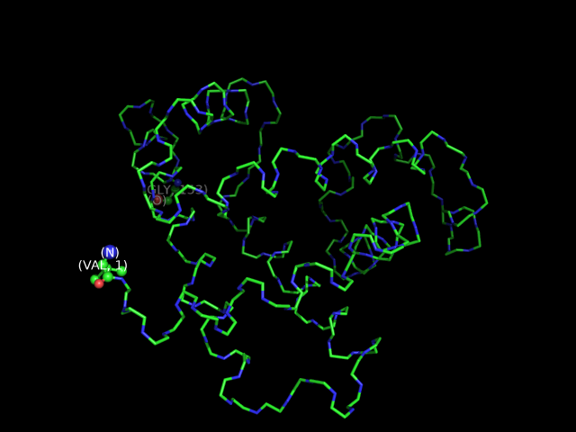

```python
Image(filename="chain.png")
```

### Дополнительные упражнения.

### Задание 5

#### Опишите общую форму заданного белка и оцените его размеры.

Получите одноцветное изображение белковой части структуры в шариковой модели. Покрутите структуру, выберите ракурс и опишите в протоколе, на что это похоже (на шар, цилиндр, гриб, гвоздь...?)  
Белок похож на **эллипсоид**

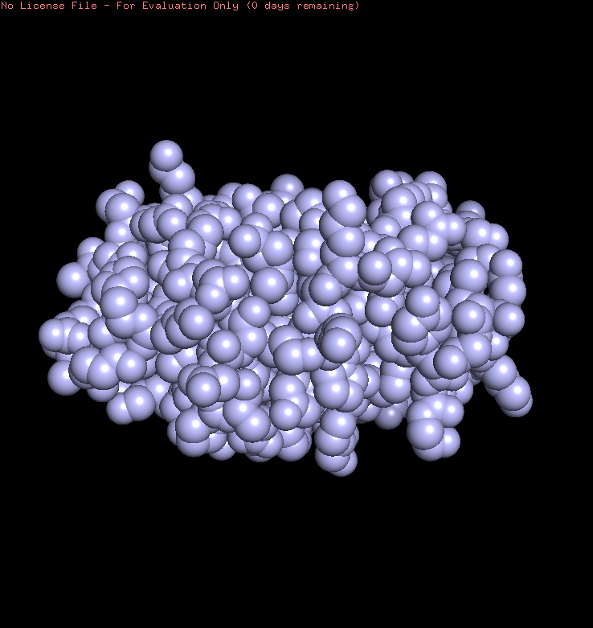

```python
Image(filename="protein.png")
```

Для измерения характерных размеров структуры используйте кнопки меню "Wizard"=>"Measurements" . На экране должна появиться пунктирная линия с указанием расстояния между точками в A. В командном окне можно увидеть, между какими атомами было измерено расстояние. Результаты занесите в протокол.

Так как белок похож на эллипсоид, то необходимо измерить три величины: *ширину*, *высоту* и *глубину*.

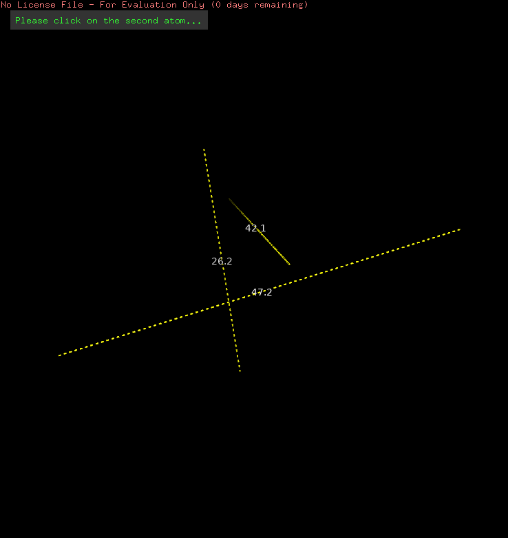

```python
Image(filename="parameters.png")
```

Для того, чтобы понять, маленький или большой белок Вам задан, очень полезно выполнить следующие расчеты. Аппроксимируйте белок сферой, радиус которой выберите на основании проведенных измерений. Допускается аппроксимация цилиндром или другой подходящей геометрической фигурой. Попробуйте ответить на следующие вопросы.

Подсчитаем объем аппроксимирующего эллипсоида. $$ V = \frac{4}{3} \pi a b c $$

```python
from math import pi
a = 42.1 / 2
b = 47.2 / 2
c = 26.2 / 2
V = 4 / 3 * a * b * c * pi
V
```

```
20444.91321969942
```

```python
r = 0.5 * 10 ** 4
h = 2 * 10 ** 4
V_coli = pi * r ** 2 * h
count = round(V_coli / V)
count
```

```
76830667.0
```

Получемется, что в клетку *Escherichia coli* уместиться **76830667** белков.  
Предположим, что все 4400 белков кишечной палочки были синтезированы одновременно и в равных количествах. Предположим, что размеры всех белков одинаковы и равны размерам Вашего белка. Предположим, что в клетке ничего нет, кроме белков. Сколькими молекулами будет представлен каждый белок?  
Нужно разделить **count** на количество белков

```python
unique_count = round(count / 4400)
unique_count
```

```
17462.0
```

**17462** молекулами будет представлен каждый белок

Предел разрешения светового микроскопа оценивается как λ/2, где λ - длина волны. Сколько молекул белка потребуется, чтобы создать объект, видимый под световым микроскопом?

```python
S = pi * a * b
number = 200 * 200 / S * 10 ** 4
number
```

```
256298.4711009225
```